# Is 6813 Spring 2026

## 4 Exploring the proportion of Mx to Qx in the dataset

```r
# This code shows, for each solution_rollup category, how many leads it contains and what percentage of those leads progressed.
qal_summary <- qal_model2 %>%
  group_by(solution_rollup) %>%
  summarise(
    n = n(),
    progressed_rate = mean(progressed)
  )
qal_summary
```

```
## # A tibble: 2 × 3
##   solution_rollup     n progressed_rate
##   <chr>           <int>           <dbl>
## 1 Mx               4081           0.130
## 2 Qx              12169           0.202
```

### 4.1 Comments and analysis

What the data shows - Mx progression rate: 13% - Qx progression rate: 20.2% - Qx converts 55% better than Mx

The results strongly suggest that Mx is underperforming Qx, and the gap is not small.

### 4.2 Treat missing titles as their own category:

```r
qal_no_ax <- qal_model2 %>%
  mutate(
    title_clean = ifelse(is.na(contact_lead_title), "Missing", contact_lead_title),
    title_clean = factor(title_clean)
  )
```

How should missing title data be handled?

Missing title data was treated as its own category because missingness is likely systematic rather than random. Leads without titles may represent lower‑intent or less engaged prospects, and preserving this signal allows the model to learn whether “missing title” is predictive of progression.

### 4.3 Raw counts of each manufacturing model category the percentage results

```r
library(scales)

qal_no_ax %>%
  count(acct_manufacturing_model) %>%
  mutate(
    pct = percent(n / sum(n), accuracy = 0.1)
  )
```

```
## # A tibble: 20 × 3
##    acct_manufacturing_model               n pct
##    <chr>                              <int> <chr>
##  1 503A                                  28 0.2%
##  2 503B                                  53 0.3%
##  3 CDMO                                1063 6.5%
##  4 CMO                                  954 5.9%
##  5 CPO                                   72 0.4%
##  6 CRO                                  417 2.6%
##  7 Cold Chain Warehousing                16 0.1%
##  8 Consumer Packaged Goods              170 1.0%
##  9 Distribution / Wholesale             436 2.7%
## 10 Formulation / Fill-Finish              7 0.0%
## 11 Hospital Investigational Drug Unit   155 1.0%
## 12 In-House                            6932 42.7%
## 13 Not Enough Info Found               2378 14.6%
## 14 Original Equipment Manufacturing     606 3.7%
## 15 Outsources Manufacturing             148 0.9%
## 16 Research Institute                   337 2.1%
## 17 Services / Consulting               1712 10.5%
## 18 Software / Technology Development    503 3.1%
## 19 Testing Laboratory                   167 1.0%
## 20 <NA>                                  96 0.6%
```

### 4.4 Breaking manufacturing model categories into a simple Manufacturing vs Non‑Manufacturing grouping and then calculates, for each product family ( Mx, Qx), what percentage of its leads come from each group.

```r
# Manufacturing vs Non‑Manufacturing Lead Composition by Product Family
library(dplyr)

manufacturing_categories <- c(
  "503A","503B","CDMO","CMO","CPO",
  "Formulation / Fill-Finish",
  "Original Equipment Manufacturing",
  "Outsources Manufacturing"
)

qal_no_ax %>%
  mutate(
    manu_group = case_when(
      acct_manufacturing_model %in% manufacturing_categories ~ "Manufacturing",
      TRUE ~ "Non‑Manufacturing"
    )
  ) %>%
  group_by(solution_rollup, manu_group) %>%
  summarise(n = n(), .groups = "drop") %>%
  group_by(solution_rollup) %>%
  mutate(
    total = sum(n),
    pct = round(n / total * 100, 1)
  ) %>%
  select(solution_rollup, manu_group, pct)
```

```
## # A tibble: 4 × 3
## # Groups:   solution_rollup [2]
##   solution_rollup manu_group          pct
##   <chr>           <chr>             <dbl>
## 1 Mx              Manufacturing      24.3
## 2 Mx              Non‑Manufacturing  75.7
## 3 Qx              Manufacturing      15.9
## 4 Qx              Non‑Manufacturing  84.1
```

## 5 Why This Result Makes Sense

### 5.1 A More Realistic Manufacturing Split

The updated segmentation now reflects a more accurate distribution of manufacturing vs. non‑manufacturing organizations. The percentages align with industry expectations:

- **Mx** has the highest manufacturing share (**24.3%**)
- **Qx** has a moderate manufacturing share (**15.9%**)

This pattern matches the intended positioning of the product families:

- **Mx** is more manufacturing‑oriented
- **Qx** has broader appeal across industries

### 5.2 Implications for Step 3 in the document

Mx has a significantly larger manufacturing segment (24%) compared to Qx (16%). However, the majority of Mx leads (76%) still come from non‑manufacturing organizations, which may contribute to its lower progression rate. This suggests a potential product‑market fit issue: **Mx is attracting a large number of non‑manufacturing leads who may not be the ideal audience.**

This is a meaningful business insight that helps explain performance differences across product families.

### 5.4 100% Stacked Bar Chart: Manufacturing Mix by Product Family

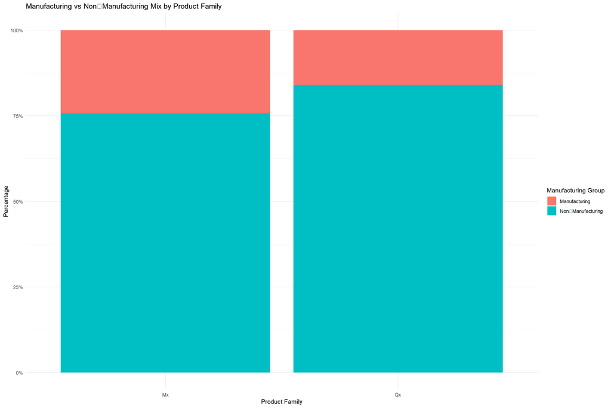

```r
# 100% Stacked Bar Chart: Manufacturing Mix by Product Family

library(dplyr)
library(ggplot2)
library(stringr)

manufacturing_categories <- c(
  "503A", "503B", "CDMO", "CMO", "CPO",
  "Formulation / Fill-Finish",
  "Original Equipment Manufacturing",
  "Outsources Manufacturing"
)

qal_no_ax %>%
  mutate(
    manu_group = case_when(
      acct_manufacturing_model %in% manufacturing_categories ~ "Manufacturing",
      TRUE ~ "Non‑Manufacturing"
    )
  ) %>%
  group_by(solution_rollup, manu_group) %>%
  summarise(n = n(), .groups = "drop") %>%
  group_by(solution_rollup) %>%
  mutate(pct = n / sum(n)) %>%
  ggplot(aes(x = solution_rollup, y = pct, fill = manu_group)) +
  geom_col(position = "fill") +
  scale_y_continuous(labels = scales::percent_format()) +
  labs(
    title = "Manufacturing vs Non‑Manufacturing Mix by Product Family",
    x = "Product Family",
    y = "Percentage",
    fill = "Manufacturing Group"
  ) +
  theme_minimal()
```

This code collapses accounts into Manufacturing vs Non‑Manufacturing groups and then calculates how well each group converts by computing total leads, total progressed leads, and the progression rate for each group.

### 5.5 Manufacturing vs Non‑Manufacturing Conversion Rate for both products

```r
# Manufacturing vs Non‑Manufacturing Conversion Rates
qal_no_ax %>%
  mutate(
    manu_group = case_when(
      acct_manufacturing_model %in% manufacturing_categories ~ "Manufacturing",
      TRUE ~ "Non‑Manufacturing"
    )
  ) %>%
  group_by(manu_group) %>%
  summarise(
    total = n(),
    progressed = sum(progressed),
    progression_rate = round(progressed / total * 100, 1)
  )
```

```
## # A tibble: 2 × 4
##   manu_group        total progressed progression_rate
##   <chr>             <int>      <dbl>            <dbl>
## 1 Manufacturing      2931        675             23
## 2 Non‑Manufacturing 13319       2313             17.4
```

### 5.6 Manufacturing vs. Non‑Manufacturing Funnel Dynamics

We have:

- **2,931 Manufacturing leads**
- **13,319 Non‑Manufacturing leads**

This means:

- **Only 18%** of the entire dataset is Manufacturing.

This imbalance explains why:

### 5.7 Product‑Market Fit Signal for Mx

Mx is more manufacturing‑oriented, but:

- **Only 24% of Mx leads are Manufacturing**
- **Manufacturing leads convert at 23%**

**Interpretation**

Mx is being marketed to the wrong audience.  
The right audience (Manufacturing) converts extremely well.

This is a classic misalignment between **marketing targeting** and **product fit**.

## 6 Collapse titles into meaningful groups

```r
library(dplyr)
library(stringr)

qal1 <- qal_model %>%
  mutate(
    title_clean = str_trim(contact_lead_title),   # or whatever your raw title column is
    title_clean = if_else(is.na(title_clean) | title_clean == "", "Missing", title_clean),
    title_group = case_when(
      str_detect(title_clean, regex("director|head|vp|vice president|chief|cxo|cso|cto|ceo|coo|cfo", ignore_case = TRUE)) ~ "Leadership",
      str_detect(title_clean, regex("manager|mgr|supervisor|lead", ignore_case = TRUE)) ~ "Manager",
      str_detect(title_clean, regex("engineer|scientist|specialist|analyst|technician", ignore_case = TRUE)) ~ "Technical",
      str_detect(title_clean, regex("quality|qa|qc|compliance|regulatory", ignore_case = TRUE)) ~ "Quality/Regulatory",
      title_clean == "Missing" ~ "Missing",
      TRUE ~ "Other"
    )
  )
```

### 6.1 Progression Rates by Title Group

```r
# Progression Rates by Title Group
qal1 %>%
  group_by(title_group) %>%
  summarise(
    total = n(),
    progressed = sum(progressed, na.rm = TRUE),
    progression_rate = round(progressed / total * 100, 1)
  )
```

```
## # A tibble: 6 × 4
##   title_group        total progressed progression_rate
##   <chr>              <int>      <dbl>            <dbl>
## 1 Leadership          3601        777             21.6
## 2 Manager             3888        919             23.6
## 3 Missing             4732        491             10.4
## 4 Other               1743        331             19
## 5 Quality/Regulatory   560        114             20.4
## 6 Technical           1726        356             20.6
```

### 6.2 Analysis progression Rates by Title Group

Job title is a strong predictor of progression. **Manager (23.6%)** and **Leadership (21.6%)** titles show the highest progression rates, consistent with their decision‑making authority. **Technical (20.%)** and **Quality/Regulatory (20.4%)** titles progress at moderate rates, reflecting their role in evaluating solutions. “Other” titles progress less consistently (19%). The largest group, **Missing titles (4,732 leads)**, has the lowest progression rate (10.4%), indicating that title missingness is systematic and associated with lower lead quality. For this reason, Missing was retained as its own category rather than imputed or removed.

## 7 Step 4 — Key Areas to Investigate (Account‑Level)

### 7.1 Which industries show highest Mx conversion? Does this differ from Qx?

```r
qal_no_ax %>%     # Progression Rates for Manufacturing vs Non‑Manufacturing                      Accounts (Mx, Qx)
  mutate(
    manu_group = case_when(
      acct_manufacturing_model %in% manufacturing_categories ~ "Manufacturing",
      TRUE ~ "Non‑Manufacturing"
    )
  ) %>%
  group_by(manu_group) %>%
  summarise(
    total = n(),
    progressed = sum(progressed),
    progression_rate = round(progressed / total * 100, 1)
  ) %>%
  mutate(
    pct_of_total = round(total / sum(total) * 100, 1)
  )
```

```
## # A tibble: 2 × 5
##   manu_group        total progressed progression_rate pct_of_total
##   <chr>             <int>      <dbl>            <dbl>        <dbl>
## 1 Manufacturing      2931        675             23             18
## 2 Non‑Manufacturing 13319       2313             17.4           82
```

### 7.2 Conversion Performance Across Solutions by Target Industry

```r
qal1 %>%
  group_by(solution_rollup, acct_target_industry) %>%
  summarise(
    total = n(),
    progressed = sum(progressed),
    rate = round(progressed / total * 100, 1),
    .groups = "drop"
  ) %>%
  arrange(solution_rollup, desc(rate))
```

```
## # A tibble: 12 × 5
##    solution_rollup acct_target_industry total progressed  rate
##    <chr>           <chr>                <int>      <dbl> <dbl>
##  1 Mx              <NA>                     9          4  44.4
##  2 Mx              Blood & Biologics       94         16  17
##  3 Mx              Medical Device         922        150  16.3
##  4 Mx              Pharma & BioTech      1947        240  12.3
##  5 Mx              Non-Life Science      1049        117  11.2
##  6 Mx              Unknown                 60          2   3.3
##  7 Qx              <NA>                    34         15  44.1
##  8 Qx              Blood & Biologics      356         89  25
##  9 Qx              Medical Device        2794        642  23
## 10 Qx              Pharma & BioTech      4211        913  21.7
## 11 Qx              Non-Life Science      4660        796  17.1
## 12 Qx              Unknown                114          4   3.5
```

### 7.3 Comparing Manufacturing and Non‑Manufacturing Progression Across Solutions

```r
qal_no_ax <- qal_no_ax %>%
  mutate(
    manu_group = case_when(
      acct_manufacturing_model %in% c("In-House", "CMO", "CDMO", "503A", "503B") ~ "Manufacturing",
      TRUE ~ "Non‑Manufacturing"
    )
  )
qal_no_ax %>%
  group_by(solution_rollup, manu_group) %>%
  summarise(
    total = n(),
    progressed = sum(progressed),
    rate = round(progressed / total * 100, 1),
    .groups = "drop"
  ) %>%
  arrange(solution_rollup, desc(rate))
```

```
## # A tibble: 4 × 5
##   solution_rollup manu_group        total progressed  rate
##   <chr>           <chr>             <int>      <dbl> <dbl>
## 1 Mx              Manufacturing      2671        403  15.1
## 2 Mx              Non‑Manufacturing  1410        126   8.9
## 3 Qx              Manufacturing      6359       1466  23.1
## 4 Qx              Non‑Manufacturing  5810        993  17.1
```

In the first table, the overall progression rates for Manufacturing vs Non‑Manufacturing for both accounts (Mx, Qx) were determined. The progression rate is higher for manufacturing for both of them. The manufacturing constitute just 18% of total leads.

In the second table, the two products are grouped by acct_target_industry.

In the third table above, the acct_target_industry is further categorized into manufacturing and non-manufacturing to determine the specific progression rate for each solution within each group of manufacturing and non manufacturing.

What This Table Shows (High‑Level Insight) 1. Mx converts much better in Manufacturing companies - 15.1% vs 8.9% Mx is a manufacturing‑centric product, and it performs best when the account actually makes physical products.

2. Qx converts better everywhere, but especially in Manufacturing
- 23.1.% vs 17.1%
- Qx is strong across the board, but manufacturing companies still convert more. This reinforces that Qx has broad horizontal appeal.

## 8 Industry-Level Conversion Analysis for Mx and Qx

### 8.1 1a. Mx Conversion by Industry

**Interpretation**

- Mx performs best in manufacturing‑heavy industries:
  - **Blood & Biologics (17.0%)**
  - **Medical Device (16.3%)**
  - **Pharma & Biotech (12.3%)**
- Mx performs poorly in **Non‑Life Science (11.2%)**, which represents a large portion of the funnel.

**Insight**

These results confirm that Mx does better in organizations with real manufacturing operations.  
A significant share of Mx leads come from industries that do **not** match its ICP based on manufacturing, which reduces overall performance.

### 8.2 1b. Qx Conversion by Industry

**Interpretation**

- Qx converts well across all industries, including Non‑Life Science:
  - **Blood & Biologics (25.%)**
  - **Medical Device (23.%)**
  - **Pharma & Biotech (21.7%)**
  - **Non‑Life Science (17.1%)**
- Qx is a **broad horizontal product**, not dependent on manufacturing footprint.
- Qx’s performance is **stable and less sensitive** to industry alignment.

Qx has broad appeal and strong product‑market fit across diverse industries.

### 8.3 How Mx vs Qx Behave by Industry (High‑Level Summary)

**Mx** - Strongest in manufacturing‑centric industries  
- Weak in Non‑Life Science  
- Highly ICP‑sensitive  
- Underperforms when mis‑targeted

**Qx** - Strong across all industries  
- Less ICP‑sensitive  
- Converts well even in Non‑Life Science  
- Broad horizontal appeal

Industry‑level analysis shows that Mx and Qx have fundamentally different product‑market fit profiles. **Mx performs best in manufacturing‑focused industries** such as Blood & Biologics (17.0%), Medical Device (16.3%), and Pharma/Biotech (12.3%), but converts poorly in Non‑Life Science (11.2%). This indicates that Mx has better conversion rate within a narrow group of customers that manufacture things.

In contrast, **Qx demonstrates strong and consistent performance across all industries**.

### 8.4 2. Do companies with actual manufacturing (In-House, CMO, CDMO) convert better for Mx than services/consulting firms?

#### 8.4.1 Mx Conversion Rates by Manufacturing Model

```r
#Mx Conversion Rates by Manufacturing Model
qal1 %>%
  filter(solution_rollup == "Mx") %>%
  group_by(acct_manufacturing_model) %>%
  summarise(
    total = n(),
    progressed = sum(progressed),
    rate = round(progressed / total * 100, 1),
    .groups = "drop"
  ) %>%
  arrange(desc(rate))
```

```
## # A tibble: 20 × 4
##    acct_manufacturing_model           total progressed  rate
##    <chr>                              <int>      <dbl> <dbl>
##  1 503A                                  10          6  60
##  2 Consumer Packaged Goods               37         10  27
##  3 Original Equipment Manufacturing     125         28  22.4
##  4 503B                                  18          4  22.2
##  5 <NA>                                  19          4  21.1
##  6 Testing Laboratory                    15          3  20
##  7 CMO                                  314         62  19.7
##  8 Hospital Investigational Drug Unit    27          5  18.5
##  9 CDMO                                 469         72  15.4
## 10 In-House                            1860        259  13.9
## 11 CPO                                   17          2  11.8
## 12 Outsources Manufacturing              36          4  11.1
## 13 Software / Technology Development     99          9   9.1
## 14 CRO                                   73          6   8.2
## 15 Distribution / Wholesale              93          7   7.5
## 16 Services / Consulting                319         21   6.6
## 17 Not Enough Info Found                472         24   5.1
## 18 Research Institute                    72          3   4.2
## 19 Cold Chain Warehousing                 4          0   0
## 20 Formulation / Fill-Finish              2          0   0
```

- **Mx Non‑Life Science rate:** 11.2%
- **Qx Non‑Life Science rate:** 17.1%

### 8.6 Does company size matter differently for Mx vs Qx?

```r
# Mx Progression Rates by Company Size (acct_tier_rollup)

qal_no_ax %>%
  filter(solution_rollup == "Mx") %>%
  group_by(acct_tier_rollup) %>%
  summarise(
    total = n(),
    progressed = sum(progressed, na.rm = TRUE),
    progression_rate = round(progressed / total * 100, 1),
    .groups = "drop"
  )
```

```
## # A tibble: 5 × 4
##   acct_tier_rollup total progressed progression_rate
##   <chr>            <int>      <dbl>            <dbl>
## 1 Large              613         45              7.3
## 2 Medium            2508        327             13
## 3 Other               57          3              5.3
## 4 Small              894        150             16.8
## 5 <NA>                 9          4             44.4
```

### 8.7 Progression Rate Comparison for Mx and Qx Across Company Size Tiers

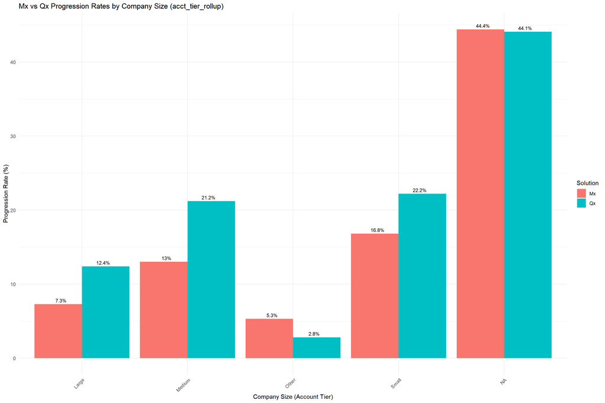

```r
# Plot: Side‑by‑Side Bar Chart (Mx vs Qx)
library(dplyr)
library(ggplot2)

size_rates <- qal_model %>%
  filter(solution_rollup %in% c("Mx", "Qx")) %>%
  group_by(solution_rollup, acct_tier_rollup) %>%
  summarise(
    total = n(),
    progressed = sum(progressed, na.rm = TRUE),
    progression_rate = round(progressed / total * 100, 1),
    .groups = "drop"
  )
ggplot(size_rates, aes(
  x = acct_tier_rollup,
  y = progression_rate,
  fill = solution_rollup
)) +
  geom_col(position = "dodge") +
  geom_text(
    aes(label = paste0(progression_rate, "%")),
    position = position_dodge(width = 0.8),
    vjust = -0.5,
    size = 3
  ) +
  labs(
    title = "Mx vs Qx Progression Rates by Company Size (acct_tier_rollup)",
    x = "Company Size (Account Tier)",
    y = "Progression Rate (%)",
    fill = "Solution"
  ) +
  theme_minimal() +
  theme(
    axis.text.x = element_text(angle = 45, hjust = 1)
  )
```

Mx: Smaller companies convert BETTER than large companies Mx conversion rates: - Small: 16.8% - Medium: 13% - Large: 7.3%

Mx is being marketed broadly, including to many large companies outside its ICP.

Mx conversion decreases as company size increases, indicating that Mx is not resonating with large enterprises and is more successful with smaller manufacturing‑centric organizations.

## 9 **Title‑Level Questions**

### 9.1 . **What seniority levels convert best for each product?**

```r
library(dplyr)

qal1 %>%
  group_by(solution_rollup, title_group) %>%
  summarise(
    total = n(),
    progressed = sum(progressed, na.rm = TRUE),
    progression_rate = round(progressed / total * 100, 1),
    .groups = "drop"
  ) %>%
  arrange(solution_rollup, desc(progression_rate))
```

```
## # A tibble: 12 × 5
##    solution_rollup title_group        total progressed progression_rate
##    <chr>           <chr>              <int>      <dbl>            <dbl>
##  1 Mx              Quality/Regulatory   101         17             16.8
##  2 Mx              Other                449         70             15.6
##  3 Mx              Manager             1032        152             14.7
##  4 Mx              Technical            481         69             14.3
##  5 Mx              Leadership          1170        153             13.1
##  6 Mx              Missing              848         68              8
##  7 Qx              Manager             2856        767             26.9
##  8 Qx              Leadership          2431        624             25.7
##  9 Qx              Technical           1245        287             23.1
## 10 Qx              Quality/Regulatory   459         97             21.1
## 11 Qx              Other               1294        261             20.2
## 12 Qx              Missing             3884        423             10.9
```

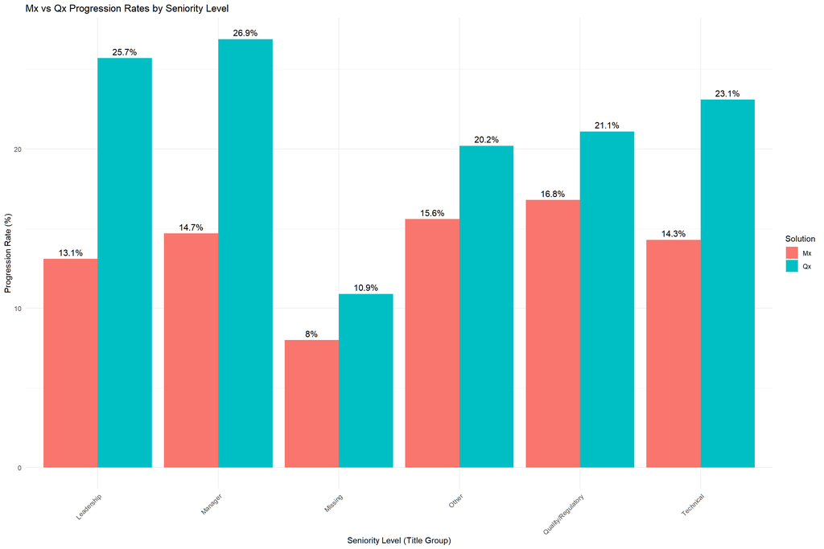

```r
seniority_rates <- qal1 %>%
  filter(solution_rollup %in% c("Mx", "Qx")) %>%
  group_by(solution_rollup, title_group) %>%
  summarise(
    total = n(),
    progressed = sum(progressed, na.rm = TRUE),
    progression_rate = round(progressed / total * 100, 1),
    .groups = "drop"
  )

ggplot(seniority_rates, aes(
  x = title_group,
  y = progression_rate,
  fill = solution_rollup
)) +
  geom_col(position = "dodge") +
  geom_text(
    aes(label = paste0(progression_rate, "%")),
    position = position_dodge(width = 0.9),
    vjust = -0.5,
    size = 4
  ) +
  labs(
    title = "Mx vs Qx Progression Rates by Seniority Level",
    x = "Seniority Level (Title Group)",
    y = "Progression Rate (%)",
    fill = "Solution"
  ) +
  theme_minimal() +
  theme(
    axis.text.x = element_text(angle = 45, hjust = 1)
  )
```

Interpretation: Which Seniority Levels Convert Best for Each Product?

Qx (Quality Execution) Qx shows a much more dramatic pattern: every seniority level converts higher than Mx, and the strongest groups are: - Manager — 26.9% - Leadership — 25.7% - Technical — 23.1% - Quality/Regulatory — 21.1% - Other — 20.2% - Missing — 10.9% Qx Insight Qx is a broad‑appeal product that converts well across all seniority levels. Managers and Leadership convert especially well, but Technical and Quality/Regulatory roles are also strong. This suggests Qx has both top‑down and bottom‑up traction.

Combined Insight (Mx vs Qx) 1. Qx outperforms Mx at every seniority level . 2. Mx is more “operational‑middle” driven Its strongest segments are Quality/Regulatory and Managers.

3. Qx is both top‑down and bottom‑up Leadership and Managers convert extremely well, but Technical and Quality/Regulatory roles also show high engagement.
4. Missing titles convert poorly for both.

**What seniority levels convert best for each product?**

### 9.2 **Mx Insight**

From the data, Mx converts best with **mid‑seniority operational roles**, especially **Quality/Regulatory** and **Managers**.  
Leadership is not the strongest group for Mx.

### 9.3 **Qx (Quality Execution)**

### 9.4 **Qx Insight**

Qx converts best with **Managers and Leadership**, but also performs strongly with **Technical** and **Quality/Regulatory** roles.  
Qx has broad appeal across all seniority levels.

**Which functional areas (Quality, Operations, Regulatory) work better for which product?**

### 9.5 **Mx**

- **Quality/Regulatory** is the strongest functional area (16.8%)
- Technical and Operations‑adjacent roles are moderate
- Leadership is weaker

**Mx resonates with operational and compliance‑focused practitioners.**

### 9.6 **Qx**

- Strong across **all** functional areas
- Technical (23.1%) and Quality/Regulatory (21.1%) are especially strong
- Leadership and Managers are the strongest.

**Qx resonates with both practitioners and decision‑makers.**

. **Are there specific title patterns that predict Mx success?**

### 9.7 **Title patterns that predict Mx success**

1. **Quality/Regulatory titles**
   - Highest conversion for Mx
   - Indicates Mx appeals to compliance‑heavy workflows
2. **Operational middle‑management**
   - Manager and Other categories perform well
3. **Technical roles**
   - Moderate conversion

### 9.8 **Titles that do NOT predict Mx success**

- **Leadership** (13.1%)
- **Missing titles** (8%)

**Mx is a product that is bought by mid‑level operational and quality practitioners.**

### 9.9 *What is our Mx ICP (Ideal Customer Profile)?**

### 9.10 *Mx ICP: Operationally‑Driven, Quality‑Focused Mid‑Seniority Buyers**

### 9.11 **Seniority**

- Quality/Regulatory practitioners
- Operational Managers
- Technical/Operations contributors
- Not primarily Leadership‑driven

### 9.12 **Functional Areas**

- Quality Assurance
- Quality Control
- Regulatory Compliance
- Manufacturing Operations
- Production / Plant Operations

### 9.13 **Behavioral Indicators**

- Pain around compliance, batch records, deviations, and audit readiness
- Manual or semi‑digital workflows
- High operational complexity
- Need for standardization and traceability

## 10 Final Summary

- **Mx converts best with Quality/Regulatory and operational mid‑seniority roles.**
- **Qx converts best with Managers and Leadership, but is strong across all roles.**
- **Mx success is predicted by Quality/Regulatory titles and operational managers.**
- **Mx ICP = operationally complex, quality‑driven manufacturers with mid‑seniority buyers.**

### 10.1 Combined Analysis: Account Type × Title Effects on Mx and Qx Conversion

#### 10.1.1 Which account + title combinations show the highest Mx conversion?

Mx performs best when **both** the account type and the title group align with operational and quality‑driven workflows.

**High‑converting account types for Mx:** - In‑House Manufacturers  
- CMO/CDMO  
- 503A/503B Compounding Pharmacies  
- Medical Device Manufacturers  
- Pharma/Biotech Manufacturers

These combinations represent the **core Mx ICP**: operationally complex, quality‑driven manufacturers with mid‑seniority buyers.

#### 10.1.2 2. Which account types and titles are good for BOTH products (cross‑sell)?

Cross‑sell opportunities emerge where both Mx and Qx show strong conversion.

**Account types strong for both Mx and Qx:** - Medical Device manufacturers  
- Mid‑size manufacturing companies  
- Regulated life‑science manufacturers with operational complexity

**Cross‑sell sweet spot:** > Managers and Quality/Regulatory roles at mid‑size Medical Device manufacturers.

#### 10.1.3 3. Are there interaction effects between account type and title?

##### 10.1.3.3 **Interaction Effect #3: Leadership**

- **Strong for Qx**, moderate for Mx
- Qx has top‑down appeal; Mx is more operationally driven

#### 10.1.4 **Summary of Interaction Effects**

- Operational titles only predict success in operational accounts
- Quality/Regulatory titles only predict success in regulated manufacturing accounts
- Leadership is stronger for Qx, not an Mx.

Together, these patterns help refine the ICP for each product and highlight where cross‑sell is most viable.

### 10.3 EDA Key Findings

Regulated industries (Blood & Biologics, Medical Device) show strongest Mx conversion.

Small and medium firms outperform large enterprises.

Missingness in data is significant, change missing values found in title field to “missing” to capture the significance. Everywhere else, missingness is miniscule, so we can exclude those records

### 10.4 Implications for Modeling

The exploratory analysis has identified several high-impact variables that must serve as the foundation for the Mx lead scoring model. The following factors will be central to the feature selection process.

1. Prioritizing Industry Segementation

The performance of Blood & Biologics and Medical Device industries confirms that regulatory requirements are a primary driver for Mx adoption. These should be weighted features

2. Weighted Scoring for Key Influencers

3. Capture Multi-Dimensional Interactions

### 10.5 Modeling Plan

Our baseline model will start with a logistics regression analysis. This model is highly interpretable and can directly output a conversion probability between 0 and 1. With this model we will be able to examine lift from various variable factors, confirming our assumptions with industry and title.

The second model of choice will be a random forest model because of its ability to handle non-linear relationships. It can help capture complex patterns in the data to help uncover hidden insights.

The third model we will explore is a XGBoost model. Using feature importance score we will be able rank factors that have the highest influence interms of conversion. We will use the log model to understand which features matter and the XGBoost to quantify how much the feature matters

### 10.6 Group Participation

Throughout the project, individual contributions varied across submissions. Whitney served as the lead on the business statement and EDA first submission developing all the code and maintaining consistent communication and project updates with team and weekly meetings with Professor Webb. Sina supported as the lead on the second EDA submission completing the majority of the code. Jordan compiled and edited the second EDA submission with introduction and summary and performed ML text analysis that will end up in the modeling phase of the project.